# Lab6-Text Analysis 101 Using R

## Learning Objects

This tutorial aims to introduce basic ways to preprocess texual data before we model data using R. We will cover:

1. How to read, clean, and transform text data
2. How to preprocess data such as tokenization, removing stop words, lemmatization, stemming, and representing words in R
3. How to get basic statistics from texts using lexicon methods

In the previous tutorial, we have covered some basics about how to read and save files in R, how to recognize regEx, and how to use selenium to do webscraping.

We were able to successfully scrape the BLM protest events dataset. You can access the dataset https://yongjunzhang.com/files/css/blm-data.tsv

Note that some of these codes in this lab tutorial came from Lab 3.

## Code Chanllenges

> 1. You need to submit a script showing you are able to run the selenium and actually gather the data
> 2. You need to scrape the original news articles using “blm-data.tsv” dataset (it has source urls) and make a structured textual data set. Some of these urls might not work or you don’t have access. It is fine that you skip those.
> 3. You have two weeks to finish this.

## Intro to Preprossing Textual Data with R

#### We need to load some packages for use

```r
require(pacman)
packages<-c("tidyverse","tidytext","rvest", "RSelenium","httr",
            "quanteda","haven","readxl","here","knitr","stopwords")
p_load(packages,character.only = TRUE)
```

#### Load blm-data tsv file

R tidyverse package provides a series of useful data wrangling tools. You can check it here https://www.tidyverse.org/. The tidyverse package installs a number of other packages for reading data:

1. **DBI** for relational databases. You’ll need to pair DBI with a database specific backends like RSQLite, RMariaDB, RPostgres, or odbc. Learn more at https://db.rstudio.com.
2. **haven** for SPSS, Stata, and SAS data.
3. **httr** for web APIs.
4. **readxl** for .xls and .xlsx sheets.
5. **rvest** for web scraping.
6. **jsonlite** for JSON. (Maintained by Jeroen Ooms.)
7. **xml2** for XML.

```r
# read tsv file using read_csv
data <- read_tsv(url("https://yongjunzhang.com/files/css/blm-data.tsv"))
# Show a table for visual check
knitr::kable(data[1:3,],cap="Black Lives Matter Protest (elephrame.com)")
```

Black Lives Matter Protest (elephrame.com)

| page_id | protest_id | protest_location | protest_start | protest_end | protest_subject | protest_participants | protest_time | protest_description | protest_urls |
| --- | --- | --- | --- | --- | --- | --- | --- | --- | --- |
| 1 | 6730 | London, England - happened? | Tuesday, October 19, 2021 | - Present | Subject(s): Local - Monument - Robert Geffyre, History - Slavery | Participant(s): Unclear | Time: Continuous | Description: Boycott of Museum of the Home over statue of Geffrye, who made money from slave trade | Source(s):##https://www.hackneycitizen.co.uk/2021/10/19/campaigners-museum-boycott-calls-teachers-families-join-slaver-statue/ |
| 1 | 4538 | Minneapolis, MN | Friday, June 5, 2020 | - Present | Subject(s): General - Police Brutality | Participant(s): 15 | Time: Continuous | Description: “Say Their Names” symbolic cemetery of 100 Black people killed by police | Source(s):##https://www.minneapolis.org/support-black-lives/38th-and-chicago/##https://theconversation.com/black-deaths-matter-the-centuries-old-struggle-to-memorialize-slaves-and-victims-of-racism-14… |
| 1 | 2948 | Minneapolis, MN | Tuesday, May 26, 2020 | - Present | Subject(s): George Floyd | Participant(s): Hundreds-Thousands (est.) | Time: Continuous | Description: Makeshift memorial at site where Floyd was killed | Source(s):##https://twitter.com/bengarvin/status/1267291981266530305##https://twitter.com/stribrooks/status/1266005779158568963##https://twitter.com/OmarJimenez/status/1265394526379806720 |

#### Clean blm-data

Let us say, we need to create variables like state and city; we also want to clean some variables like subjects, description, etc.

```r
data <- data %>%
  # split location
  separate(protest_location,c("city","state"),sep = ",",remove = T) %>%
  # split protest start time
  separate(protest_start,c("day","date","year"),sep = ",",remove = T) %>%
  # clean subjects and participants
  mutate(
    protest_subject = str_replace(protest_subject,"Subject\\(s\\): ",""),
    protest_participants = str_replace(protest_participants,"Participant\\(s\\): ",""),
    protest_time = str_replace(protest_time,"Time: ",""),
    protest_description = str_replace(protest_description,"Description: ",""),
    protest_urls = str_replace(protest_urls,"Source\\(s\\):","")
    )
# Show a table for visual check
knitr::kable(data[1:3,],cap="Black Lives Matter Protest (elephrame.com)")
```

Black Lives Matter Protest (elephrame.com)

| page_id | protest_id | city | state | day | date | year | protest_end | protest_subject | protest_participants | protest_time | protest_description | protest_urls |
| --- | --- | --- | --- | --- | --- | --- | --- | --- | --- | --- | --- | --- |
| 1 | 6730 | London | England - happened? | Tuesday | October 19 | 2021 | - Present | Local - Monument - Robert Geffyre, History - Slavery | Unclear | Continuous | Boycott of Museum of the Home over statue of Geffrye, who made money from slave trade | ##https://www.hackneycitizen.co.uk/2021/10/19/campaigners-museum-boycott-calls-teachers-families-join-slaver-statue/ |
| 1 | 4538 | Minneapolis | MN | Friday | June 5 | 2020 | - Present | General - Police Brutality | 15 | Continuous | “Say Their Names” symbolic cemetery of 100 Black people killed by police | ##https://www.minneapolis.org/support-black-lives/38th-and-chicago/##https://theconversation.com/black-deaths-matter-the-centuries-old-struggle-to-memorialize-slaves-and-victims-of-racism-140613##http… |
| 1 | 2948 | Minneapolis | MN | Tuesday | May 26 | 2020 | - Present | George Floyd | Hundreds-Thousands (est.) | Continuous | Makeshift memorial at site where Floyd was killed | ##https://twitter.com/bengarvin/status/1267291981266530305##https://twitter.com/stribrooks/status/1266005779158568963##https://twitter.com/OmarJimenez/status/1265394526379806720 |

### Using Tidytest package to process some variables

There are a variety of processing text packages. Today we briefly introduce tidytext package. You can check herehttps://cran.r-project.org/web/packages/tidytext/vignettes/tidytext.html; This tidytext toturial heavily relies on Julia Silge and David Robinson’s work. You can also check their book Text Mining with R here https://www.tidytextmining.com/

```r
library(tidytext)

# Let us say we are interested in protest description. We need to restructure it as one-token-per-row format. The unnest_tokens function is a way to convert a dataframe with a text column to be one-token-per-row:

tidy_data <- data %>%
  # protest_urls is messay, let us get rid of it first
  select(-protest_urls) %>%
  # one token per row. This function uses the tokenizers package to separate each line into words. The default tokenizing is for words, but other options include characters, ngrams, sentences, lines, paragraphs, or separation around a regex pattern.
  unnest_tokens(word, protest_description) %>%
  # remove stop words
  anti_join(tidytext::get_stopwords("en",source="snowball")) %>%
  # you can also add your own stop words if you want
  # check here to see tibble data structure <https://tibble.tidyverse.org/>
  anti_join(tibble(word=c("no","details")),by="word")
knitr::kable(tidy_data[1:10,],cap="Black Lives Matter Protest (elephrame.com)")
```

Black Lives Matter Protest (elephrame.com)

| page_id | protest_id | city | state | day | date | year | protest_end | protest_subject | protest_participants | protest_time | word |
| --- | --- | --- | --- | --- | --- | --- | --- | --- | --- | --- | --- |
| 1 | 6730 | London | England - happened? | Tuesday | October 19 | 2021 | - Present | Local - Monument - Robert Geffyre, History - Slavery | Unclear | Continuous | boycott |
| 1 | 6730 | London | England - happened? | Tuesday | October 19 | 2021 | - Present | Local - Monument - Robert Geffyre, History - Slavery | Unclear | Continuous | museum |
| 1 | 6730 | London | England - happened? | Tuesday | October 19 | 2021 | - Present | Local - Monument - Robert Geffyre, History - Slavery | Unclear | Continuous | home |
| 1 | 6730 | London | England - happened? | Tuesday | October 19 | 2021 | - Present | Local - Monument - Robert Geffyre, History - Slavery | Unclear | Continuous | statue |
| 1 | 6730 | London | England - happened? | Tuesday | October 19 | 2021 | - Present | Local - Monument - Robert Geffyre, History - Slavery | Unclear | Continuous | geffrye |
| 1 | 6730 | London | England - happened? | Tuesday | October 19 | 2021 | - Present | Local - Monument - Robert Geffyre, History - Slavery | Unclear | Continuous | made |
| 1 | 6730 | London | England - happened? | Tuesday | October 19 | 2021 | - Present | Local - Monument - Robert Geffyre, History - Slavery | Unclear | Continuous | money |
| 1 | 6730 | London | England - happened? | Tuesday | October 19 | 2021 | - Present | Local - Monument - Robert Geffyre, History - Slavery | Unclear | Continuous | slave |
| 1 | 6730 | London | England - happened? | Tuesday | October 19 | 2021 | - Present | Local - Monument - Robert Geffyre, History - Slavery | Unclear | Continuous | trade |
| 1 | 4538 | Minneapolis | MN | Friday | June 5 | 2020 | - Present | General - Police Brutality | 15 | Continuous | say |

```r
# let us see what stopwords we are excluding
stopwords_d <- tidytext::get_stopwords()
stopwords_d$word
```

```
##   [1] "i"          "me"         "my"         "myself"     "we"
##   [6] "our"        "ours"       "ourselves"  "you"        "your"
##  [11] "yours"      "yourself"   "yourselves" "he"         "him"
##  [16] "his"        "himself"    "she"        "her"        "hers"
##  [21] "herself"    "it"         "its"        "itself"     "they"
##  [26] "them"       "their"      "theirs"     "themselves" "what"
##  [31] "which"      "who"        "whom"       "this"       "that"
##  [36] "these"      "those"      "am"         "is"         "are"
##  [41] "was"        "were"       "be"         "been"       "being"
##  [46] "have"       "has"        "had"        "having"     "do"
##  [51] "does"       "did"        "doing"      "would"      "should"
##  [56] "could"      "ought"      "i'm"        "you're"     "he's"
##  [61] "she's"      "it's"       "we're"      "they're"    "i've"
##  [66] "you've"     "we've"      "they've"    "i'd"        "you'd"
##  [71] "he'd"       "she'd"      "we'd"       "they'd"     "i'll"
```

[output cut: 20 more lines]

## Basic Analysis of Textual Data

### Let us get a count vector for protest description, like what are the most frequent words or bi-grams

```r
tidy_data %>%
  count(word, sort = TRUE)
```

```
## # A tibble: 4,628 × 2
##    word              n
##    <chr>         <int>
##  1 demonstration  2005
##  2 included       1995
##  3 march          1284
##  4 rally          1002
##  5 outside         575
##  6 police          502
##  7 national        478
##  8 walkout         458
##  9 game            432
## 10 anthem          426
## # … with 4,618 more rows
```

We can further plot this! I don’t like wordcloud, so I just do a simple bar plot.

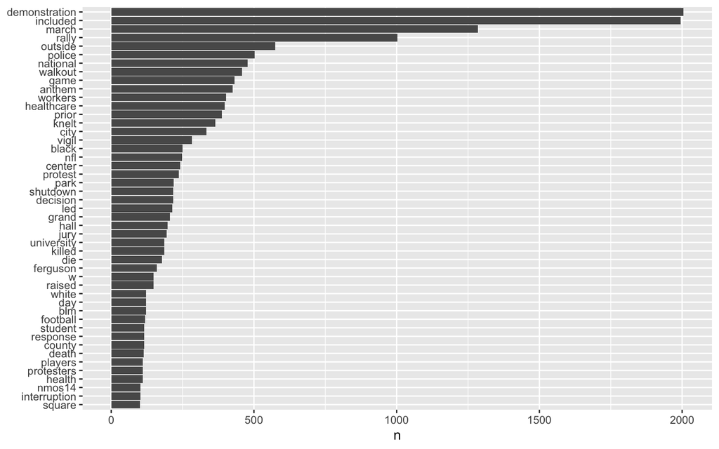

```r
library(ggplot2)

tidy_data %>%
  count(word, sort = TRUE) %>%
  filter(n > 100) %>%
  mutate(word = reorder(word, n)) %>%
  ggplot(aes(word, n)) +
  geom_col() +
  xlab(NULL) +
  coord_flip()
```

**let us get bigram**

```r
 data %>%
  select(-protest_urls) %>%
  unnest_tokens(bigram, protest_description,token = "ngrams", n = 2) %>%
  count(bigram,sort = TRUE)
```

```
## # A tibble: 14,844 × 2
##    bigram                 n
##    <chr>              <int>
##  1 for this            1968
##  2 no details          1968
##  3 this demonstration  1954
##  4 details included    1953
##  5 included for        1953
##  6 national anthem      408
##  7 healthcare workers   389
##  8 walkout of           388
##  9 prior to             387
## 10 during national      383
## # … with 14,834 more rows
```

Note you can use joining functions to filter these words or ngrams… such as inner_join, anti_join, semi_join, etc.

**We can also use tidytext to build document-term matrix or tf-idf. We will cover this next time when we talk about topic modeling.**

> In the lecture, we briefly mentioned how we represent text in NLP. In Text as Data, the authors mainly summarized the approach of “bag of words” (CoW). It is just one approach to quantify what a document is about. How important a word may be in your document or in the entire corpus (collection of documents)?

> One measure of the importance of a word is its term frequency (tf). It captures the frequency of a word in a document. There are very frequent words in a document but may not be important; in English, some stopwords, like “the”, “is”, “of”, “and”, etc. So we need to remove them before analysis based on your research. But for other scholar’s that might be of their interest.

> Another way is to look at a term’s inverse document frequency (idf), which decreases the weight for commonly used words and increases the weight for words that are not used very much in a collection of documents.

> This can be combined with term frequency to calculate a term’s tf-idf (the two quantities multiplied together), the frequency of a term adjusted for how rarely it is used.

You can check text mining with R book here https://www.tidytextmining.com/tfidf.html#tfidf

```r
tidy_words <- tidy_data %>%
  count(protest_id, word, sort = TRUE)

tidy_words
```

```
## # A tibble: 34,317 × 3
##    protest_id word        n
##         <dbl> <chr>   <int>
##  1       2414 march       4
##  2       1370 square      3
##  3       1480 high        3
##  4       2556 police      3
##  5       2767 city        3
##  6       4501 center      3
##  7       4753 workers     3
##  8       5762 nevada      3
##  9       6020 police      3
## 10         11 w           2
## # … with 34,307 more rows
```

> The idea of tf-idf is to find the important words for the content of each document by decreasing the weight for commonly used words and increasing the weight for words that are not used very much in a collection or corpus of documents.

> The bind_tf_idf function in the tidytext package takes a tidy text dataset as input with one row per token (term), per document. One column (word here) contains the terms/tokens, one column contains the documents (book in this case), and the last necessary column contains the counts, how many times each document contains each term.

```r
tidy_words <- tidy_words %>%
  bind_tf_idf(word, protest_id, n)

tidy_words
```

```
## # A tibble: 34,317 × 6
##    protest_id word        n    tf   idf tf_idf
##         <dbl> <chr>   <int> <dbl> <dbl>  <dbl>
##  1       2414 march       4 0.222  1.68  0.373
##  2       1370 square      3 0.188  4.27  0.800
##  3       1480 high        3 0.176  5.20  0.917
##  4       2556 police      3 0.231  2.63  0.607
##  5       2767 city        3 0.188  3.07  0.575
##  6       4501 center      3 0.25   3.34  0.835
##  7       4753 workers     3 0.231  2.83  0.653
##  8       5762 nevada      3 0.2    8.12  1.62
##  9       6020 police      3 0.167  2.63  0.439
## 10         11 w           2 0.182  3.85  0.699
## # … with 34,307 more rows
```

Let us take a look at those relatively important words

[figure not shown]

```r
tidy_words %>%
  arrange(desc(tf_idf)) %>%
  mutate(word = factor(word, levels = rev(unique(word)))) %>%
  group_by(protest_id) %>%
  filter(protest_id%in%sample(2000:5000, 4, replace=F)) %>%
  top_n(10) %>%
  ungroup() %>%
  ggplot(aes(word, tf_idf, fill = protest_id)) +
  geom_col(show.legend = FALSE) +
  labs(x = NULL, y = "tf-idf") +
  facet_wrap(~protest_id, ncol = 2, scales = "free") +
  coord_flip()
```

## Use RSelenium Package to Obtain Data

Let us say we want to go deeper about BLM data. The BLM-DATA.TSV provides the original protest urls (news articles). We want to process those original articles to get more info.

### Let us use rselenium package to scrape a couple of news articles for example.

Here is a tutorial by Josh McCrain http://joshuamccrain.com/tutorials/web_scraping_R_selenium.html

```r
# create a dataset having urls, year, and ids
urls <- data %>%
  select(protest_id,state,date,protest_urls) %>%
  # let us extract all protest_urls
  mutate(protest_urls=str_replace_all(protest_urls,"^##|^#","")) %>%
  separate_rows(protest_urls,sep="##") %>%
  filter(str_detect(protest_urls,"^http"))

# only keep one url for each protest
urls1 <- urls %>%
  distinct(protest_id,.keep_all = T)

# let us take a look at the data
knitr::kable(urls1[1:5,],cap="Black Lives Matter Protest (elephrame.com)")
```

Black Lives Matter Protest (elephrame.com)

| protest_id | state | date | protest_urls |
| --- | --- | --- | --- |
| 6730 | England - happened? | October 19 | https://www.hackneycitizen.co.uk/2021/10/19/campaigners-museum-boycott-calls-teachers-families-join-slaver-statue/ |
| 4538 | MN | June 5 | https://www.minneapolis.org/support-black-lives/38th-and-chicago/ |
| 2948 | MN | May 26 | https://twitter.com/bengarvin/status/1267291981266530305 |
| 6754 | MN | February 5 | https://www.startribune.com/protest-of-police-killing-of-amir-locke-draws-hundreds-to-minneapolis/600143527/ |
| 6755 | MN | February 4 | https://minnesota.cbslocal.com/2022/02/05/car-caravan-rolls-through-downtown-minneapolis-in-protest-of-amir-locke-killing/ |

> You need to use RSelenium to scrape these dynamic websites; we have learnt basic Selenium stuff in python. You can read this turorial for more details http://joshuamccrain.com/tutorials/web_scraping_R_selenium.html We also have a tutorial using python selenium to scrape data in previous lab.

### Here let me briefly show you we can also do this in R

```r
# connect to chrome driver
driver <- RSelenium::rsDriver(browser = "firefox",port=4567L, verbose=F)
remote_driver <- driver[["client"]]
remote_driver$navigate(urls1$protest_urls[1])
```

```r
# retrieve the article

main_article <- remote_driver$findElement(using = "id", value="fl-post-254675")

text <- main_article$getElementText()
```

```r
driver[["server"]]$stop()
```

```
## [1] TRUE
```

```r
gc(driver)
```

```
##           used  (Mb) gc trigger  (Mb) limit (Mb) max used  (Mb)
## Ncells 2972654 158.8    5581532 298.1         NA  5581532 298.1
## Vcells 6210446  47.4   12255594  93.6     102400 10146317  77.5
```

```r
rm(driver)
```

### Text is a messy list, you need to do some cleaning again.

```r
# let us clean those special characters like \n \t, etc.

tidy_text <- text[[1]] %>%
  # remove all whitespaces, note it is regex \t
  str_replace_all("\\s"," ") %>%
  # reove some weird punct
  str_replace_all('\\"',"") %>%
  # remove some double spaces
  str_squish %>%
  # reve spaces at the begining and end of the text
  str_trim %>%
  # lower case
  tolower()

tidy_text
```

```
## [1] "campaigners ramp up museum boycott with calls for teachers and families to join them until slaver statue is removed by julia gregory, local democracy reporter | tuesday 19 october 2021 at 19:22 campaigners have been protesting against the statue for more than a year campaigners are calling f…
```

**VOILA, we have a nice tidy text!!!**

> You can write a loop to go through all these urls and scrape the entire page for each url. Later then you clean and build a database.

### Let us then use quanteda package do some text processing in R (FINALLY :))

Check here for Quantedahttps://quanteda.io/articles/pkgdown/quickstart.html

> quanteda, Quantitative Analysis of Textual Data, is an R package for managing and analyzing textual data developed by Kenneth Benoit, Kohei Watanabe, and other contributors.

> The package is designed for R users needing to apply natural language processing to texts, from documents to final analysis. Its capabilities match or exceed those provided in many end-user software applications, many of which are expensive and not open source. The package is therefore of great benefit to researchers, students, and other analysts with fewer financial resources. While using quanteda requires R programming knowledge, its API is designed to enable powerful, efficient analysis with a minimum of steps. By emphasizing consistent design, furthermore, quanteda lowers the barriers to learning and using NLP and quantitative text analysis even for proficient R programmers.

> You are also encourage to install several recommended packages, including readtext, spacyr, and quanteda.corpora.

In this part, we however use some new york times articles to run analysis. If you manage to obtain all protest articles, you can use these protest articles as well. If not, you can use the small sample of nyt dataset. It has title_doca, text, and title_proquest. The title_doca ALLOWs you to merge nyt articles with doca data.

Note that you can download the doca raw dataset from this link: https://web.stanford.edu/group/collectiveaction/cgi-bin/drupal/. Then you can merge doca data with nyt articles. Ideally you can treat doca dataset as your TRAINING dataset, and you can train some models to predict protest related outcomes.

```r
load("./doca_nyt.rdata")
```

#### Let us build a doca nyt corpus

Quanteda has a corpus constructor command corpus(): - a vector of character objects, for instance that you have already loaded into the workspace using other tools; - a VCorpus corpus object from the tm package. - a data.frame containing a text column and any other document-level metadata

.

```r
doca_nyt_corpus <- corpus(doca_nyt)  # build a new corpus from the texts
#summary(doca_nyt_corpus)
```

##### How a quanteda corpus works

> A corpus is designed to be a “library” of original documents that have been converted to plain, UTF-8 encoded text, and stored along with meta-data at the corpus level and at the document-level. We have a special name for document-level meta-data: docvars. These are variables or features that describe attributes of each document.

> A corpus is designed to be a more or less static container of texts with respect to processing and analysis. This means that the texts in corpus are not designed to be changed internally through (for example) cleaning or pre-processing steps, such as stemming or removing punctuation. Rather, texts can be extracted from the corpus as part of processing, and assigned to new objects, but the idea is that the corpus will remain as an original reference copy so that other analyses – for instance those in which stems and punctuation were required, such as analyzing a reading ease index – can be performed on the same corpus.

> To extract texts from a corpus, we use an extractor, called texts().

```r
texts(doca_nyt_corpus)[2]
```

```
##                                                                                                                                                                                                                                                                                                          …
## "Homosexuals at Harvard Protesting Navy Hiring\n‘New York Times (1923-Current file); Mar 21, 1983: ProQuest Historical Newspapers: The New York Times\nps. Al2\n\nHomosexuals at Harvard\nProtesting Navy Hiring\n\nCAMBRIDGE, Mass., March 20 (AP)\n— A drive by homosexual students at\nHarvard Univers…
```

> Exploring corpus texts: The kwic function (keywords-in-context) performs a search for a word and allows us to view the contexts in which it occurs:

```r
kwic(doca_nyt_corpus, "protest",valuetype = "regex")
```

```
##
##        [text2, 4]
##       [text2, 35]
##       [text8, 10]
##       [text8, 57]
##       [text18, 9]
##      [text18, 49]
##     [text25, 508]
##     [text25, 545]
##     [text27, 827]
##       [text28, 7]
##      [text28, 42]
##     [text28, 156]
##     [text28, 662]
##    [text29, 1022]
##    [text29, 1055]
##    [text29, 1160]
##    [text29, 1220]
##       [text30, 5]
##      [text30, 38]
##       [text32, 9]
##      [text32, 60]
##     [text32, 106]
##       [text35, 2]
##      [text35, 27]
##      [text35, 38]
##       [text38, 8]
##      [text38, 53]
##     [text40, 393]
##      [text41, 92]
##     [text41, 219]
##     [text41, 301]
##     [text41, 504]
##     [text41, 930]
##     [text46, 131]
##      [text48, 61]
##     [text48, 189]
##     [text48, 249]
##     [text48, 441]
##     [text50, 136]
```

[output cut: 7917 more lines]

```
##       protests      | froze the city of Wichita
##      Protesters     | had hoped convention week would
##       protests      | as a backdrop to the
##       protests      | outside clinics had returned to
##      protesters     | last month to hold a
##      protesters     | showed up to be shouted
##       protests      | at the clinics and a
##      protesters     | from interfering with clinics.
##       protest       | at the clinics. But
##      protesters     | over a network of 72
##       protests      | so furious that they have
##       protests      | that have forced some to
##      protesters     | maintain that they do not
##       protest       | noise, sanitation problems,
##       protests      | and the proposed legislation as
```

> Tokenize texts: To simply tokenize a text, quanteda provides a powerful command called tokens(). This produces an intermediate object, consisting of a list of tokens in the form of character vectors, where each element of the list corresponds to an input document.

```r
tokens(texts(doca_nyt_corpus)[2],remove_numbers = TRUE, remove_punct = TRUE, remove_separators = TRUE)
```

```
## Tokens consisting of 1 document.
## text2 :
##  [1] "Homosexuals"  "at"           "Harvard"      "Protesting"   "Navy"
##  [6] "Hiring"       "New"          "York"         "Times"        "1923-Current"
## [11] "file"         "Mar"
## [ ... and 178 more ]
```

Constructing a document-feature matrix

Tokenizing texts is an intermediate option, and most users will want to skip straight to constructing a document-feature matrix. For this, we have a Swiss-army knife function, called dfm(), which performs tokenization and tabulates the extracted features into a matrix of documents by features. Unlike the conservative approach taken by tokens(), the dfm() function applies certain options by default, such as tolower() – a separate function for lower-casing texts – and removes punctuation.

```r
# make a dfm
my_dfm <- dfm(doca_nyt_corpus, remove = stopwords("english"), stem = TRUE, remove_punct = TRUE)
my_dfm[, 1:5]
```

```
## Document-feature matrix of: 2,000 documents, 5 features (80.8% sparse) and 2 docvars.
##        features
## docs    dinkin lead call stop street
##   text1      8    3    8    6     10
##   text2      0    0    0    0      0
##   text3      0    0    0    0      0
##   text4      0    0    3    0      0
##   text5      0    1    0    1      6
##   text6      0    0    2    0      2
## [ reached max_ndoc ... 1,994 more documents ]
```

> Viewing the document-feature matrix: The dfm can be inspected in the Enviroment pane in RStudio, or by calling R’s View function. Calling plot on a dfm will display a wordcloud.

```r
topfeatures(my_dfm, 20)  # 20 top words
```

```
##      said       new         |      time      york        mr   permiss    school
##     10883      8439      6963      6711      6660      5553      4398      3716
##   student     state      citi     group     polic     black   without   protest
##      3523      3372      2978      2916      2836      2728      2674      2620
##       one copyright     owner      year
##      2574      2485      2462      2407
```

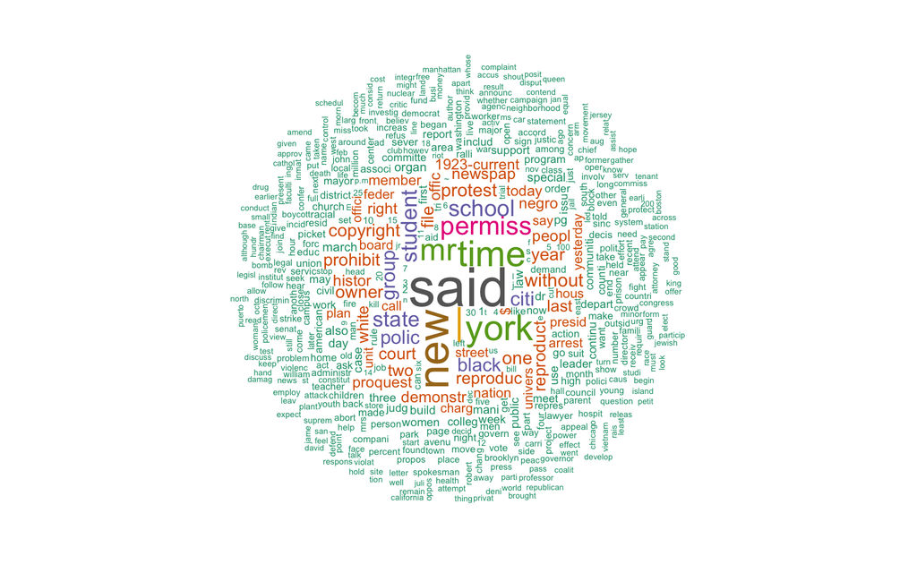

```r
set.seed(100)
textplot_wordcloud(my_dfm, min_count = 6, random_order = FALSE,
                   rotation = .25,
                   colors = RColorBrewer::brewer.pal(8,"Dark2"))
```

> term similarities

```r
sim <- textstat_simil(my_dfm, my_dfm[, c("protest", "demonst", "student")],
                      method = "cosine", margin = "features")
lapply(as.list(sim), head, 10)
```

```
## $protest
##      permiss    reproduct     proquest     reproduc 1923-current     demonstr
##    0.5171692    0.5134348    0.5124899    0.5110776    0.5059638    0.5029151
##    copyright         york     prohibit      without
##    0.5025317    0.4985626    0.4913091    0.4880232
##
## $demonst
##  sonspeci      fre2    spcech    ascend   disacre safeauard    nublic   cerruti
## 0.4082483 0.4082483 0.4082483 0.4082483 0.4082483 0.4082483 0.4082483 0.4082483
##  16-block  riotscar
## 0.4082483 0.4082483
##
## $student
##    campus   univers    colleg   faculti     class    demand      dent administr
## 0.7033191 0.6401076 0.5833331 0.4972651 0.4505656 0.4388754 0.3952023 0.3910930
##   without  columbia
## 0.3889639 0.3881382
```